# Informe

2023-07-07

# 1. Introducción

## Relevancia

En el estudio anterior se analizaron los patrones estadísticos de alumnos de UTEC del ciclo 2022-2 respecto a sus hábitos, gestión del estrés y rendimiento académico. En este informe se da un paso más allá y se analizan estos datos bajo la probabilidad. Esto nos sirve como herramienta para encontrar numéricamente relaciones entre variables, probabilidades y generar modelos que nos permitan producir predicciones respecto al comportamiento de la población estudiada.

## Objetivos

Nuestro proyecto tiene los siguientes objetivos:

### Objetivo general:

Analizar probabilísticamente la relación entre los hábitos de estudio y de vida de los estudiantes de UTEC durante el ciclo académico 2022-2, y cómo se correlacionan con el manejo del estrés y el rendimiento académico.

### Objetivos específicos:

Identificar las probabilidades empíricas de variables estudiadas en la encuesta.

Estudiar la dependencia que puede existir entre hábitos y medidores de rendimiento académico.

Definir variables aleatorias discretas y continuas y generar modelos que nos permitan realizar predicciones probabilísticas

Profundizar de forma práctica en los conocimientos relacionados a la Probabilidad.

### Contexto

Este estudio está basado en la información recolectada anteriormente en el estudio estadístico. Para este informe, se aplicarán conocimientos de probabilidades. Una definición básica de esta área es el estudio de qué tan posible es que ocurra un evento determinado, bajo distintas herramientas de estudio. Se emplearán conceptos como probabilidad empírica, condicional, teorema de Bayes y Probabilidad Total, modelos de distribución de V.A. Discretas y modelos de distribución de V.A. Continuas y descriptores numéricos. Cada uno de estos temas se irá desarrollando a lo largo de este proyecto.

# 2. Análisis descriptivo.

## 2.1 Análisis descriptivo univariado

### Promedio Ponderado

Esta es una variable numérica continua y se describe como el promedio obtenido en el ciclo pasado. Los valores son números no negativo con dos cifras decimales

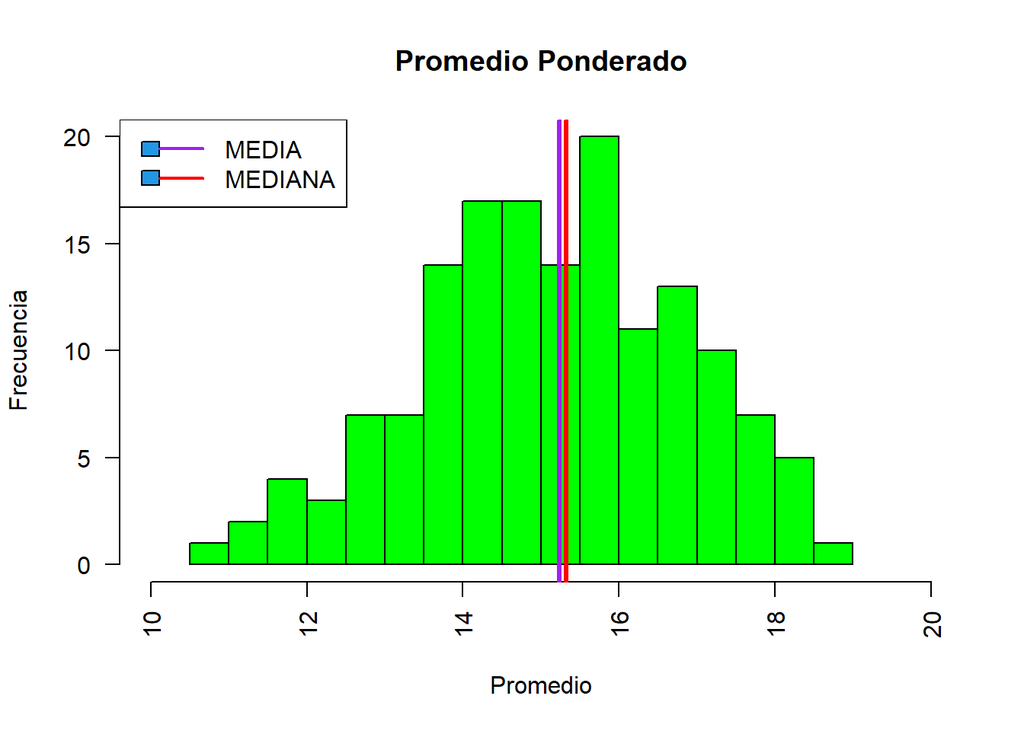

- **ANÁLISIS**
- La gráfica muestra que el promedio oscila entre 10.51 y 18.75, [10.51 - 18.75]. Podemos decir que el mínimo promedio ponderado es de 10.51 mientras que el máximo es de 18.75 durante el ciclo académico 2022-2.

```
## [1] 10.51 18.75
```

- El valor central o mediana del promedio ponderado de los alumnos es de 15.32.

```
## [1] 15.32
```

- El valor del promedio general o media aritmética de las notas es 15.24

```
## [1] 15.24
```

*Al comparar la mediana con la media aritmética del promedio Ponderado de los alumnos, podemos apreciar que la mediana es ligeramente mayor que la media, lo cual nos indica que la distribución de los valores tiende a estar ligeramente inclinada o sesgada hacia la izquierda*

### Estrés

Esta es una variable categórica ordinal y se describe como el nivel de estrés experimentado durante el ciclo. Las posibles respuestas son: 1. Nada estresado / Tranquilo 2. Algo estresado 3. Estresado 4. Saquenme de UTEC (Alto nivel de estrés).

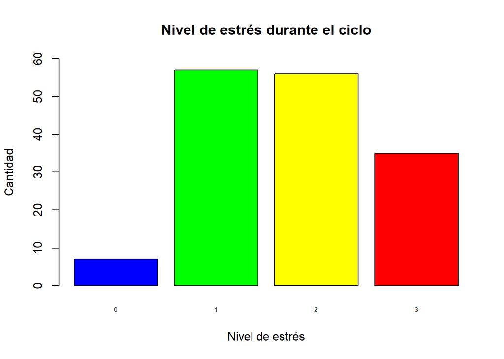

- **ANÁLISIS**

-En la gráfica de niveles de estrés durante el ciclo, podemos apreciar que el nivel de estrés de los estudiantes en su mayoría es estresado o algo estresado, además el nivel de estrés de una minoría de estudiantes ha sido tranquilo.  
-La cantidad de estudiantes que estuvieron *algo estresado* de es 57, mientras que la cantidad de *estresado* es de 56.  
- Solo 7 alumnos del total de encuestados no sufrieron de *Estrés*.

### ¿El estudiante cumplió sus expectativas?

Esta variable es categórica ordinal y muestra si el estudiante cumplió sus expectativas durante del ciclo 2022-2. Las posibles respuestas son: 1. 1 (No las cumplí) 2. 2 (No las cumplí pero estuve cerca) 3. 3 (Las cumplí) 4. 4 (Las superé) 5. 5 (Las superé por bastante)

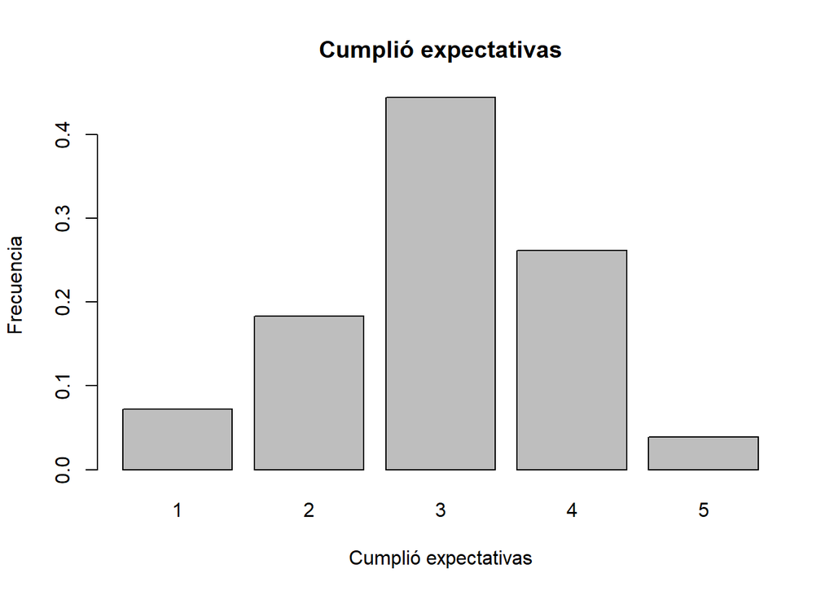

```r
barplot(prop.table(table(DT1$cumplio_exp)), main= "Cumplió expectativas", ylab= "Frecuencia", xlab = "Cumplió expectativas")
```

Podemos observar cómo la opción con más respuestas es aquella de simplemente **“cumplir sus expectativas”**.

### ¿El estudiante medita?

Esta es una variable categórica cualitativa y mide si el estudiante medita o realiza alguna práctica de mindfullness

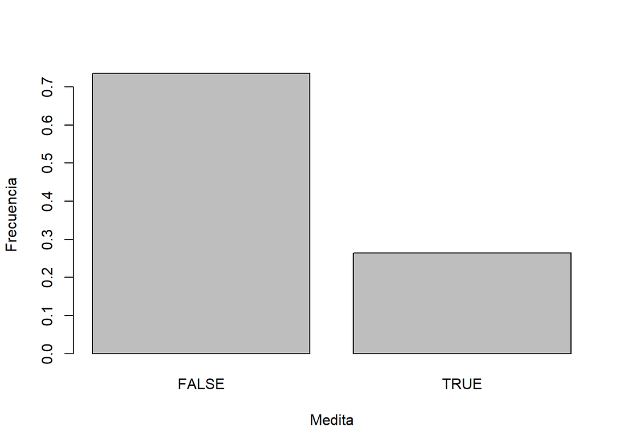

```r
barplot(prop.table(table(DT1$Medita)), ylab= "Frecuencia", xlab = "Medita")
```

A través de esta gráfica observamos cómo son la minoría los estudiantes que tienen el hábito de meditar. Ocupan el 26,4% de la muestra.

### Cantidad de estudiantes por carrera

Esta es una variable categórica cualitativa. Pregunta por la carrera en la que estudian los participantes del experimento. Las opciones son las carreras ofrecidas por UTEC.

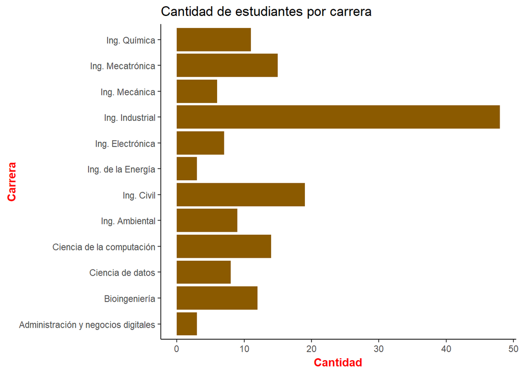

Del total de encuestados 48 estudiantes son de las carrera de ingeniería industrial, es la carrera que más se repite y es la moda de nuestra gráfica *cantidad de estudiantes por carrera*, mientras que tuvimos menos participación de los estudiantes de la carrera de administración y negocios digitales, y de la carrera de Ing. de la Energía, puesto que solo fueron 3 encuestados en ambas carreras.

### Cantidad de agua bebida a diario por los participantes del estudio (en mL)

Esta es una variable numérica continua. Los valores posibles son números naturales.

[figure not shown]

```r
hist(pull(DT1[9]), prob = T, main = "Agua", xlab = "mL de agua diarios", ylab = "Frecuencia", col="orange",breaks = 30,las=2)
lines(density(pull(DT1[9]), na.rm = T), lwd = 2, col="red")
abline(v=median(pull(DT1[9]),na.rm = TRUE),col="blue",lwd=3)
abline(v=mean(pull(DT1[9]),na.rm = TRUE),col="green",lwd=3)
legend(100,140,
       x="topleft",
       legend=c("MEDIA","MEDIANA"),
       #inset = 0.1,
       col=c("blue","green"),
       lwd=2)
```

## Análisis descriptivo bivariado

### Cumplimiento de expectativas vs promedio obtenido

Este análisis se centra en comparar el rendimiento académico promedio de los alumnos con su percepción sobre el cumplimiento de sus expectativas académicas.

**GRÁFICA - Comparación entre cumplimiento de expectativas y promedio ponderado**

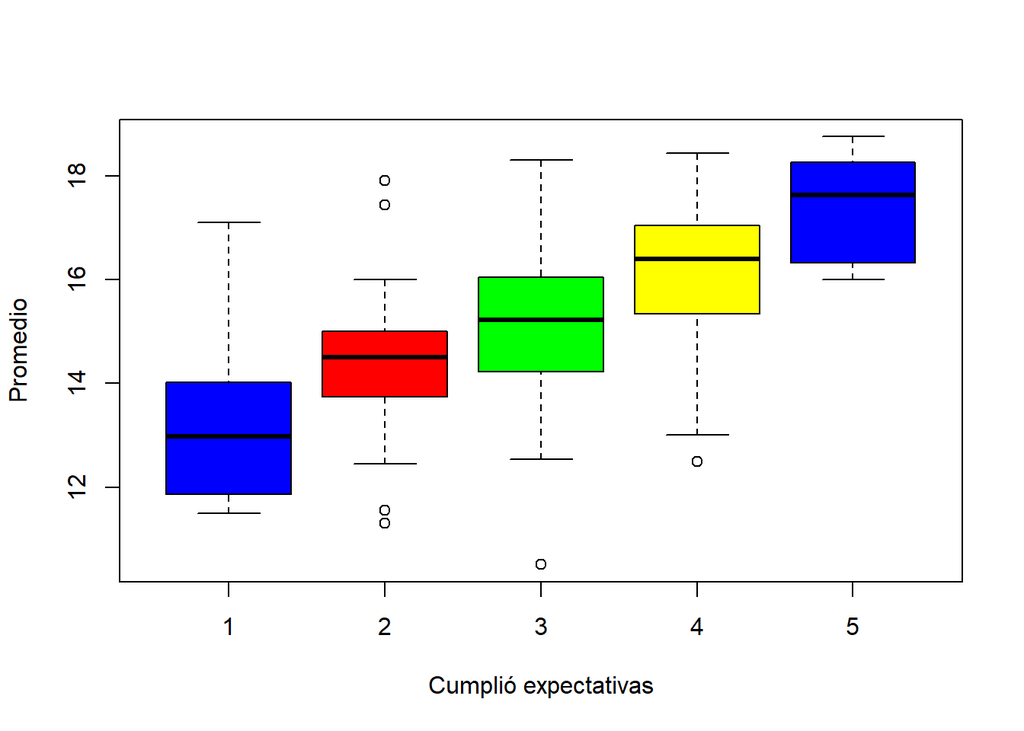

- **ANÁLISIS**

Este es el análisis bivariado más importante que se encontró en todo el experimento. Muestra cómo efectivamente un mayor cumplimiento de expectativas se relaciona directamente con un mayor promedio. Claramente se observan variaciones, pero el patrón es visible.

### Cumplió expectativas vs tener el hábito de meditar

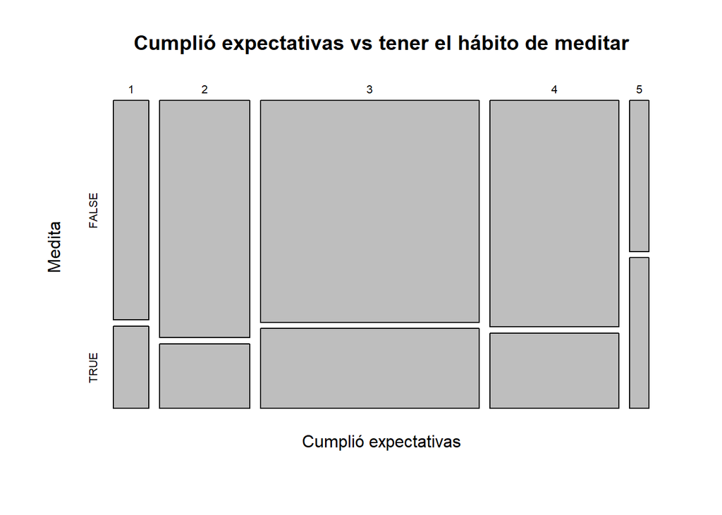

```r
mosaicplot(DT1$cumplio_exp~DT1$Medita, main="Cumplió expectativas vs tener el hábito de meditar", ylab="Medita", xlab="Cumplió expectativas")
```

**ANÁLISIS** En esta gráfica observamos cómo en realidad no existe una relación marcada entre cumplir o no sus expectativas y tener el hábito de meditar. Si esta relación existiese, esta gráfica de mosaico tendría un patrón similar a una escalera.

# 3. Análisis probabilístico

## **Cálculo de probabilidades empíricas**

### *1. Promedios de estudiantes en el ciclo 2022-2*

##### **Experimento:**

**Experimento:** Seleccionar un participante del estudio: “Análisis de la relación entre los hábitos, la gestión del estrés y el rendimiento académico en los estudiantes de UTEC en el ciclo académico 2022-2” y observar si su promedio está en el rango de notas (0,4], (4,8], (8,12], (12,16] o (16,20].

##### **Espacio muestral:**

Ω = {(0,4] (4,8] (8,12] (12,16] (16,20]}

##### **Donde cada evento atómico significa:**

[output not shown]

### *Cálculo de las probabilidades empíricas de cada evento atómico*

```r
intervalos_promedios <- cut(DT1$Promedio, breaks = c(0, 4, 8, 12, 16, 20))
round(prop.table(table(intervalos_promedios)),2)
```

```
## intervalos_promedios
##   (0,4]   (4,8]  (8,12] (12,16] (16,20]
##    0.00    0.00    0.05    0.65    0.31
```

##### **En este caso:**

| (0,4] -> | 0.00 |
| --- | --- |
| (4,8] -> | 0.00 |
| (8,12] -> | 0.05 |
| (12,16] -> | 0.65 |
| (16,20] -> | 0.31 |

### *2. El nivel de estrés del estudiante durante el ciclo 2022-2*

##### **Experimento:**

Seleccionar un participante del estudio: “Análisis de la relación entre los hábitos, la gestión del estrés y el rendimiento académico en los estudiantes de UTEC en el ciclo académico 2022-2” y observar su respuesta respecto a cuál fue su nivel de estrés durante el ciclo 2022-2.

##### **Espacio muestral:**

Ω = {0,1,2,3}

##### **Donde cada evento atómico significa:**

[output not shown]

### *Cálculo de las probabilidades empíricas de cada evento atómico*

```r
round(prop.table(table(DT1$Estres)),2)
```

```
##
##    0    1    2    3
## 0.05 0.37 0.36 0.23
```

##### **En este caso:**

| 0 (nada estresado) -> | 0.05 |
| --- | --- |
| 1 (algo estresado) -> | 0.37 |
| 2 (bastante estresado) -> | 0.36 |
| 3 (demasiado estresado) -> | 0.23 |

Estos datos nos muestran cómo son muy pocos los estudiantes que no han estado nada estresados. Es decir, siempre presentan cierto nivel de estrés, concentrado alrededor de algo y bastante estresado, principalmente.

## **Cálculo de probabilidades condicionales**

#### *Eventos dependientes (Superar por bastante sus expectativas y tener un promedio mayor o igual a 16)*

##### **Definición de eventos:**

**A**: Seleccionar un participante del estudio “Análisis de la relación entre los hábitos, la gestión del estrés y el rendimiento académico en los estudiantes de UTEC en el ciclo académico 2022-2” y observar que ha superado por bastante sus expectativas.

**B**: Seleccionar un participante del estudio “Análisis de la relación entre los hábitos, la gestión del estrés y el rendimiento académico en los estudiantes de UTEC en el ciclo académico 2022-2” y observar que tiene un promedio mayor o igual a 16.

##### **Probabilidades empíricas de estos eventos**

```r
round(prop.table(table(DT1$cumplio_exp==5)),2)
```

```
##
## FALSE  TRUE
##  0.96  0.04
```

```r
round(prop.table(table(DT1$Promedio >= 16)),2)
```

```
##
## FALSE  TRUE
##  0.64  0.36
```

##### **Validación de dependencia**

1. Cálculo de probabilidad de la intersección de ambos eventos:

```r
DT1 %>%
  filter(cumplio_exp == 5 & Promedio >= 16) %>%
  nrow() -> interseccion

round(interseccion / nrow(DT1),2)
```

```
## [1] 0.04
```

2. Cálculo de la multiplicación de la probabilidad de cada evento independientemente:

```r
supero <- sum(DT1$cumplio_exp == 5, na.rm=TRUE) / nrow(DT1)
nota <- sum(DT1$Promedio >= 16, na.rm=TRUE) / nrow(DT1)

round(supero * nota,2)
```

```
## [1] 0.01
```

3. Validación: Observamos que los resultados obtenidos son distintos (0.04 y 0.01). Esto nos indica que los eventos tienen un grado de dependencia
4. Cálculo de la probabilidad de A dado que ocurre B

```r
subconjunto <- subset(DT1, Promedio >= 16)

round(prop.table(table(subconjunto$cumplio_exp == 5)),2)
```

```
##
## FALSE  TRUE
##  0.89  0.11
```

Se observa que la probabilidad del evento A aumenta drásticamente si ocurre B. Pasa de 0.04 a 0.11.

5. Cálculo de la probabilidad de B dado que ocurre A (a posteriori)

```r
subconjunto <- subset(DT1, cumplio_exp == 5)

prop.table(table(subconjunto$Promedio >= 16))
```

```
##
## TRUE
##    1
```

**APLICACIÓN DEL TEOREMA DE BAYES Y PROBABILIDAD TOTAL**

Otra forma de calcular esta probabilidad es a través del empleo del teorema de Bayes y la probabalidad total

Para ello, primero creamos una tabla de contingencia ayudándonos del siguiente comando

```r
round(prop.table(table(DT1$Promedio >= 16, DT1$cumplio_exp == 5)),2)
```

| tabla de contingencia | A’ | A | Total |
| --- | --- | --- | --- |
| B’ | 0.64 | 0.00 | 0.64 |
| B | 0.32 | 0. 04 | 0.36 |
| Total | 0.96 | 0.04 | 1 |

Donde se P(A) = 0.04 también puede conseguirse también a través del teorema de probabilidad total:
$$P(A)=P(A|B)
* P(B) + P(A|B') * P(B')$$

```r
pa <- ((0.04)/0.36)*0.36 + ((0.00)/0.64)*0.64
pa
```

```
## [1] 0.04
```

Con estos datos aplicamos el teorema de Bayes
$$P(B|A) = \frac{P(A|B) * B}{A}$$
$$P(B|A) = \frac{0.11 * 0.36}{0.04}$$

```r
(0.11) * 0.36 / 0.04
```

```
## [1] 0.99
```

$$P(B|A) = \frac{0.11 * 0.36}{0.04} =
0.99$$

**OBSERVACIONES:** Se observa que el evento B a posteriori de la ocurrencia de A es, en este caso, **seguro**. Se muestra que siempre que el participante haya superado por bastante sus expectativas, tendrá un promedio mayor o igual a 16.

##### **Definición de eventos:**

**A**: Seleccionar un participante del estudio “Análisis de la relación entre los hábitos, la gestión del estrés y el rendimiento académico en los estudiantes de UTEC en el ciclo académico 2022-2” y observar que tiene más de 17 años.

**B**: Seleccionar un participante del estudio “Análisis de la relación entre los hábitos, la gestión del estrés y el rendimiento académico en los estudiantes de UTEC en el ciclo académico 2022-2” y observar que tiene el hábito de meditar.

##### **Probabilidades empíricas de estos eventos**

```r
round(prop.table(table(DT1$Edad > 17)),2)
```

```
##
## FALSE  TRUE
##   0.1   0.9
```

```r
round(prop.table(table(DT1$Medita == TRUE)),2)
```

```
##
## FALSE  TRUE
##  0.74  0.26
```

##### **Validación de dependencia**

1. Cálculo de probabilidad de la intersección de ambos eventos:

```r
DT1 %>%
  filter(Edad > 17 & Medita == TRUE) %>%
  nrow() -> interseccion

round(interseccion / nrow(DT1),2)
```

```
## [1] 0.23
```

2. Cálculo de la multiplicación de la probabilidad de cada evento independientemente:

```r
mayor <- sum(DT1$Edad > 17, na.rm=TRUE) / nrow(DT1)
medita <- sum(DT1$Medita == TRUE, na.rm=TRUE) / nrow(DT1)

round(mayor * medita,2)
```

```
## [1] 0.24
```

3. Validación: Observamos que los resultados obtenidos son muy similares (0.23 y 0.24). Esto nos indica que los eventos son independientes.
4. Cálculo de la probabilidad de A dado que ocurre B

```r
subconjunto <- subset(DT1, Medita == TRUE)

round(prop.table(table(subconjunto$Edad > 17)),2)
```

```
##
## FALSE  TRUE
##  0.15  0.85
```

Se observa que la probabilidad del evento no presenta un cambio significativo por el hecho de que ocurra B. Pasa de 0.9 a 0.85.

5. Cálculo de la probabilidad de B dado que ocurre A (a posteriori)

```r
subconjunto <- subset(DT1, Edad > 17)

round(prop.table(table(subconjunto$Medita == TRUE)),2)
```

```
##
## FALSE  TRUE
##  0.75  0.25
```

```r
round(0.85 /mayor * medita,2)
```

```
## [1] 0.25
```

**APLICACIÓN DEL TEOREMA DE BAYES Y PROBABILIDAD TOTAL**

Otra forma de calcular esta probabilidad es a través del empleo del teorema de Bayes y la probabalidad total

Para ello, primero creamos una tabla de contingencia ayudándonos del siguiente comando

```r
round(prop.table(table(DT1$Medita == TRUE, DT1$Edad > 17)),2)
```

| tabla de contingencia | A’ | A | Total |
| --- | --- | --- | --- |
| B’ | 0.06 | 0.67 | 0.73 |
| B | 0.04 | 0.23 | 0.27 |
| Total | 0.10 | 0.90 | 1 |

Donde se P(A) = 0.9 también puede conseguirse también a través del teorema de probabilidad total:
$$P(A)=P(A|B)
* P(B) + P(A|B') * P(B')$$

```r
pa <- ((0.23)/0.27)*0.27 + ((0.67)/0.73)*0.73
pa
```

```
## [1] 0.9
```

Con estos datos aplicamos el teorema de Bayes
$$P(B|A) = \frac{P(A|B) * B}{A}$$
$$P(B|A) = \frac{0.85 * 0.27}{0.9}$$

```r
(0.85) * 0.27 / 0.9
```

```
## [1] 0.255
```

$$P(B|A) = \frac{0.85 * 0.27}{0.9} =
0.255$$

**OBSERVACIÓN** En este caso se observa que tampoco hay una diferencia significativa en la probabilidad. Se pasa de 0.26 a 0.25.

### *Variable Aleatoria Discreta: Nivel de estrés*

**OBJETIVO:** Analizar la variable **Nivel de estrés**

```
##
##    0    1    2    3
## 0.05 0.37 0.36 0.23
```

| *Niveles* | *Probabilidad* | *Unidad* |
| --- | --- | --- |
| *Nada estresado* | 0.05 | Probabilidad que se escoja el nivel *Nada estresado* |
| *Algo estresado* | 0.37 | Probabilidad que se escoja el nivel *Algo estresado* |
| *Estresado* | 0.36 | Probabilidad que se escoja el nivel *Estresado* |
| *Muy estresado* | 0.23 | Probabilidad que se escoja el nivel *Muy estresado* |

```
##
##  0  1  2  3
##  7 57 56 35
```

#### **Variables aleatorias**

- Números de estudiantes de la **UTEC** que se encuentra en los niveles de *algo o nada estresado* dentro de un conjunto de 55 alumnos del estudio seleccionados al azar.

#### **Probabilidad de exito**

- La variable X que cuenta el número de estudiantes que se encuentran en los niveles de algo o nada estresado sigue una distribución binomial con los parámetros n y p, donde n es el número total de pruebas (55) y p es la probabilidad de éxito, que se puede estimar a partir de los datos de la muestra. En este caso, p es igual al número de éxitos entre el número total de pruebas, es decir:

$$p=\frac{(7 +
57)}{155}=\frac{64}{155}≈0.41$$

Por lo tanto, la variable X sigue una distribución binomial con los siguientes parámetros:

$$X∼B(n,p)$$
$$X∼B(55,0.41)$$

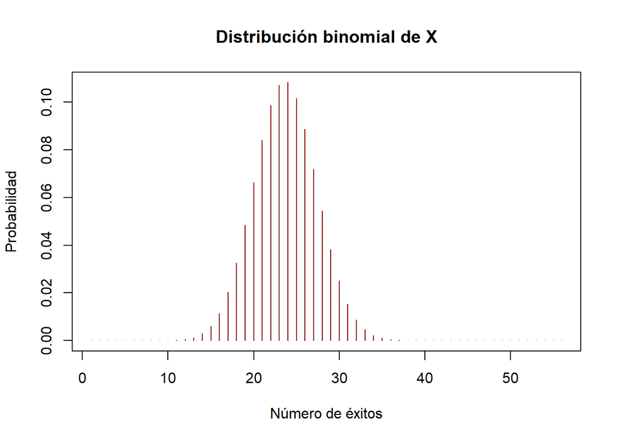

#### **Verificacion de datos**

- Por teoria:
  $$E(X)=\sum X*P(X)$$

```
## [1] 22.55
```

```
## La esperanza por teoria es:  22.55
```

- Por formula de binomial:

$$E(X)= n*p$$

> n=55

> p=0,41

```
## La esperanza por formula es:  22.55
```

#### **Ejemplos:**

###### **Ejemplo 1**

- Hallar el número de estudiantes que se encuentran en el nivel algo o nada estresado en el conjunto de 55 pruebas.

Como es una distribución binomio utilizaremos la formula:
$$P(X=x)=\begin{vmatrix}
n \\
x\\
\end{vmatrix}p^x (1-p)^{n-x}$$

Es decir, se espera que haya unos 23 estudiantes en el nivel algo o nada estresado en las 55 pruebas.

###### **Ejemplo 2.**

Para resolver este problema, usamos la variable discreta binomial y la probabilidad de éxito ya planteados. Es decir, la variable es el número de encuestados en el nivel algo o nada estresado en la muestra de 20, que puede tomar valores entre 0 y 20. Y la probabilidad de éxito es 0.41. Entonces, usando la fórmula de la distribución binomial, tenemos:

$$P(X=x)=\begin{vmatrix}
n \\
x\\
\end{vmatrix}p^x (1-p)^{n-x}$$

Donde **n** es el número de encuestados en la muestra, que es 20, **x** es el número de éxitos y **p** es la probabilidad de éxito. Entonces, para hallar la probabilidad de que al menos 15 de ellos se encuentren en el nivel algo o nada estresado, debemos sumar las probabilidades de que haya exactamente 15, 16, 17, 18, 19 o 20 encuestados en ese nivel.

Para obtener el resultado más rápidamente, utilizamos el código de R:

```r
pbinom(14, 20, 0.41, lower.tail = FALSE)
```

```
## [1] 0.002166851
```

### *Distribución Geométrica:*

#### **Pregunta 1:**

**¿Cuál es la probabilidad de encontrar que un estudiante de ingeniería industrial tenga un nivel de 3 de estrés en la prueba número 7?**

**Definición de variable aleatoria:** Número de ensayo en el que se obtendrá el primer estudiante con un nivel de estrés 3 dentro de una muestra de estudiantes de ingeniería industrial que participaron del experimento

**Identificación de parámetros:** X ~ Geom(p)

Donde p es la probabilidad de éxito. El éxito está definido como que un estudiante dentro de la muestra mencionada elegido al azar tenga un nivel de estrés 3.

**Análisis de la variable** Cantidad de estudiantes de ingeniería industrial entre los encuestados

```r
sum(DT1$Carrera == "Ing. Industrial")
```

```
## [1] 48
```

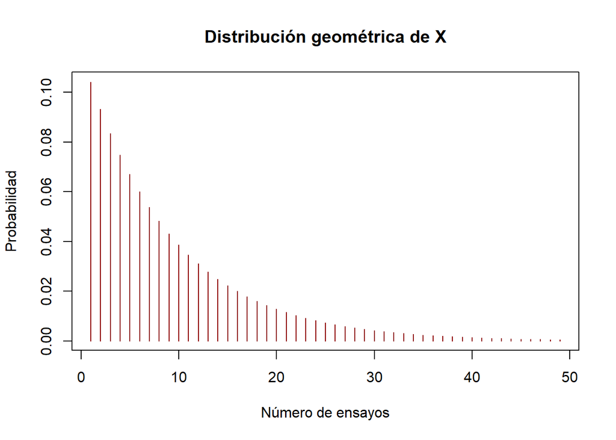

Dentro de los participantes que están en la carrera de ingeniería industrial (total=48), hay 5 que tienen un nivel de estrés 3:
$$P(éxito) \;=\; \frac{5}{48}=0.104$$
**Validación de las propiedades**
$$E = \frac{1}{p} = 9.62$$

$$V = \frac{1-p}{p^2} = 82.84$$

Con estos datos, empleamos el siguiente código para hallar la probabilidad de la pregunta inicial

```r
Civ_tr <- dgeom(6,0.104)

porcent_civ_tr <- round(Civ_tr *100,2)
porcent_civ_tr
```

```
## [1] 5.38
```

Obtenemos que la probabilidad de que si se elige al azar un estudiante que estudia ingeniería industrial y que participó del experimento, se obtenga uno que tenga un nivel 3 de estrés en el 7mo ensayo es de 5.38 %.

### *Variable Aleatoria-Continua*

> Variable de estudio: Promedio

#### **Gráfica de la variable aleatoria continua**

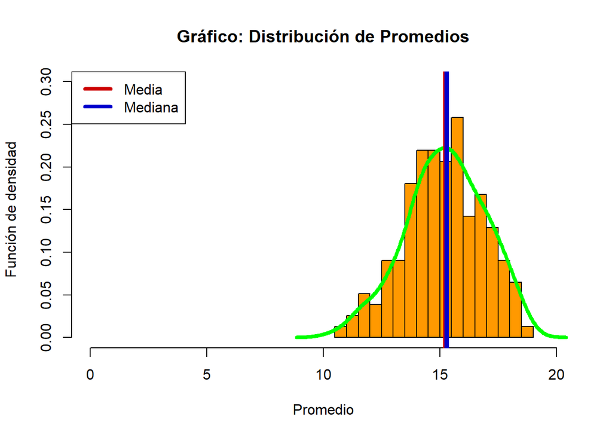

#### *Validación de una distribución normal*

> **Primera Validación**

$$X ≈ Me$$
> *X* *representa el promedio aritmetico*

La mediana y la media tiene una variación mínima por ello podemos concluir que se aproxima a una distribución normal.

> *Segunda forma de validación*

$$E(x) = \int_{-\infty}^{\infty} X * f(x)
{\ dx}$$

$$μ(Base\ datos) = E(X)$$

La esperanza de la variable aleatoria X es de: 15.24

La media de la variable Promedio ponderado es de: 15.24

> **Tercera forma de validación**

$$V(X) = \int_{\ - \infty}^{\infty}
{(X-E[X]}\ )^2 \ * \ f(X) \, dx$$

$$V(X) = {σ(\ BD)}^2 = {desviación\
estandar\ base\ datos}^2$$

La varianza de la *variable aleatoria X* es de: 2.89

## Parámetros

$$X \frac{~} \ {N(μ , σ)}$$

μ-> Es la media

σ-> Es la desviación estándar

[output not shown]

#### **Ejemplos:**

**Ejemplo 1:**

La variable promedio ponderado de los estudiantes de la UTEC lleva una distribución normal con una media de 15.24 y una desviación estándar de 1.69. ¿Cuál es la probabilidad de que el promedio sea menor que 17?

$$N(15.24 , 1.69)$$

$$P( X \leq 17)$$

- Hallando la probabilidad en R

```r
prob7<-round(pnorm(17,15.24,1.69),2)

cat("La probabilidad de que el promedio ponderado del estudiante sea menor a 17 es:", prob7 )
```

```
## La probabilidad de que el promedio ponderado del estudiante sea menor a 17 es: 0.85
```

**Ejemplo 2:**

La variable promedio ponderado de los estudiantes de la UTEC lleva una distribución normal con una media de 15.24 y una desviación estándar de 1.69. ¿Cuál es la probabilidad de que el promedio ponderado este entre 15 y 17?

- Hallando la probabilidad en R

```r
pr<-round((pnorm(17,15.24,1.69) - pnorm(15,15.24,1.69) ) * 100,2)

cat("La probabilidad de que el pormedio ponderado este entre 15 y 17 es de :", pr)
```

```
## La probabilidad de que el pormedio ponderado este entre 15 y 17 es de : 40.76
```

### *Variable Aleatoria-Continua*

> Variable de estudio: Cantidad de agua consumida a diario

La variable continua que ahora hemos considerado es la cantidad de agua consumida por los alumnos de UTEC, representada por la variable Q.

$$Q∼Nor(μx,σx)$$

*Parametros* Los parámetros μx y σx representan la media y la desviación estándar de la variable *Agua*.

$$μx = 1.326863$$
$$σx = 0.9819881$$

Para dar mayor claridad a nuestro análisis, es importante destacar que hemos realizado una transformación en los datos de la variable “Agua” para expresar las cantidades en litros en lugar de mililitros.

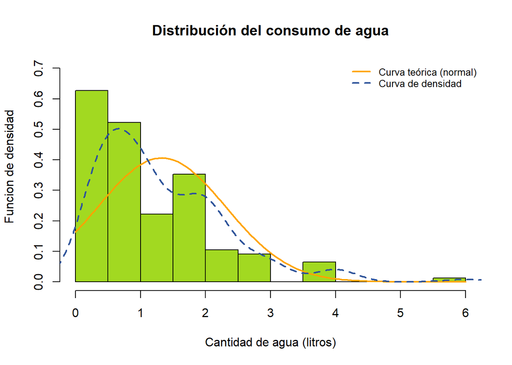

El gráfico muestra el histograma de la distribución de consumo de agua, donde se representan las frecuencias de los diferentes intervalos de consumo, sobre la cual se ha trazado la curva normal teórica.

Observaciones y análisis:

Después de analizar la variable “Agua”, se observa que presenta una distribución asimétrica positiva, indicando un sesgo hacia la derecha. La mayoría de los alumnos (alrededor del 50%) consumen entre 0.5 y 2 litros de agua. Estos resultados revelan una concentración significativa de consumidores en el rango de menor consumo.

**Caso probabilístico:**

```r
pnorm(6,μ_q,σ_q)-pnorm(2.5,μ_q,σ_q)
```

```
## [1] 0.1161099
```

Se ha determinado que la probabilidad de que los estudiantes de UTEC consuman entre 2.5 litros y 6 litros de agua por día es del 11.61%. Esto indica que una proporción relativamente pequeña de estudiantes se encuentra dentro de ese rango de consumo específico, mientras que la mayoría tiende a consumir cantidades de agua más bajas.

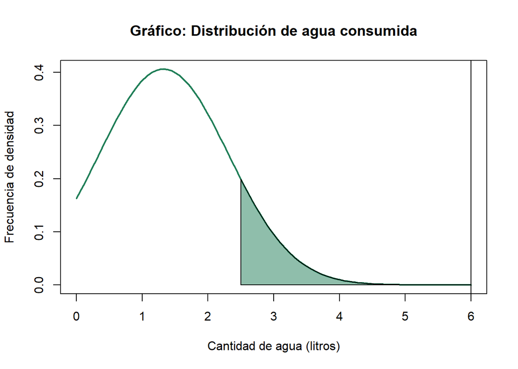

# Conclusiones